# Assignment

c) Spending Behaviour

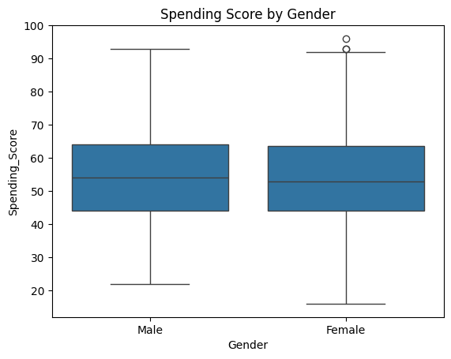

```
Spending Score by Age Group:
Age Group
18-30    45.820847
31-45    56.388889
46-60    71.612344
61-70          NaN
Name: Spending_Score, dtype: float64
```

```python
# Spending Score by Gender
 sns.boxplot(data=data, x='Gender', y='Spending_Score')
 plt.title('Spending Score by Gender')
 plt.show()
 # Spending Score by Age Group
 data['Age Group'] = pd.cut(data['Age'], bins=[18, 30, 45, 60, 70], labels=['18-30',
'31-45', '46-60', '61-70'])
 spending_by_age = data.groupby('Age Group')['Spending_Score'].mean()
 print("Spending Score by Age Group:")
 print(spending_by_age)
```

1. Spending Score by Gender:

No significant difference: The box plots for both genders show similar distributions with medians around 50-55. This suggests that gender alone does not significantly influence spending score. 2. Spending Score by Age Group (Table):

Increasing trend with age: The spending score tends to increase with age. The 46-60 age group has the highest average spending score (71.61), followed by 31-45 (56.39), and 18-30 (45.82). 3. Insights on Customer Loyalty:

Age as a factor: The increasing spending score with age suggests that older customers might be more loyal and have higher lifetime value. They might be more established in their careers and have higher disposable incomes.

Income as a factor: While not directly shown in the chart, it's likely that income plays a significant role in spending score. Higher-income individuals tend to spend more, which might be contributing to the higher scores of older age groups.

Gender as a factor: Gender does not appear to be a major factor in spending score.

d) Product Category Preferences

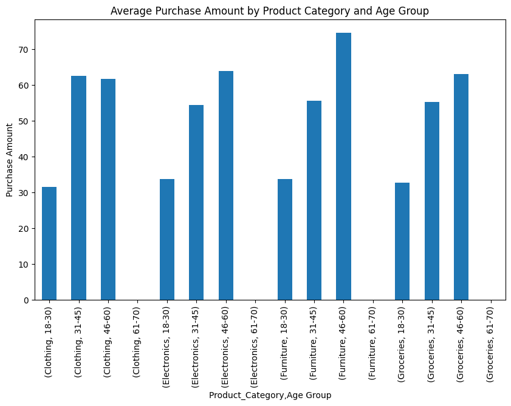

```python
# Popular product categories by income
product_income = data.groupby(['Product_Category','Age Group'])['Purchase_Amount'].mean()
product_income.plot(kind='bar', figsize=(10, 6))
plt.title('Average Purchase Amount by Product Category and Age Group')
plt.ylabel('Purchase Amount')
plt.show()
```

Observations from the Chart:

The chart displays the average purchase amount for different product categories across various age groups. Here's a breakdown of the insights:

Product Popularity:

46-60: This age group demonstrates a clear preference for furniture, indicating that older consumers might be more inclined to invest in home furnishings.

Here are some strategies MarketEase can employ to promote specific products to different segments based on the insights:

1. Target Electronics:

18-30: Focus on the latest gadgets, gaming consoles, and smart devices. 31-45: Highlight tech products for home and office, such as laptops, tablets, and smart home devices. 46-60: Promote durable electronics like washing machines, refrigerators, and TVs. 61-70: Offer discounts and special deals on essential electronics like smartphones and tablets. 2. Target Clothing:

18-30: Showcase trendy and fashionable clothing, particularly fast fashion and streetwear. 31-45: Offer a mix of casual and formal wear, including business attire and workwear. 46-60: Promote comfortable and stylish clothing, such as activewear and loungewear. 61-70: Focus on classic and timeless clothing styles, including tailored suits and dresses. 3. Target Furniture:

18-30: Highlight compact and modern furniture pieces suitable for small spaces. 31-45: Offer a range of furniture options for families, including dining sets, bedroom sets, and living room furniture. 46-60: Promote comfortable and functional furniture, such as recliners, adjustable beds, and ergonomic chairs. 61-70: Focus on easy-to-maintain furniture with classic designs. 4. Target Groceries:

18-30: Offer healthy and convenient food options, such as meal kits and organic products. 31-45: Promote family-friendly products, including snacks, beverages, and household essentials. 46-60: Offer a mix of healthy and indulgent food options, including gourmet products and specialty items. 61-70: Focus on easy-to-prepare meals and dietary-specific products.

# 3) Inferential Analytics

a) Gender Difference in Purchase Patterns

```python
from scipy.stats import ttest_ind
 # Male vs Female Purchase Amount
 male_purchase = data[data['Gender'] == 'Male']['Purchase_Amount']
 female_purchase = data[data['Gender'] == 'Female']['Purchase_Amount']
 t_stat, p_value = ttest_ind(male_purchase, female_purchase)
 print(f"T-statistic: {t_stat}, P-value: {p_value}")
```

```
T-statistic: 0.3888835926293084, P-value: 0.6974452126305676
```

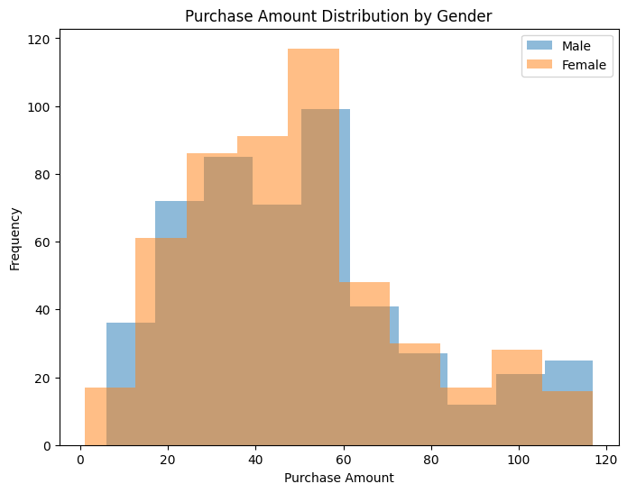

```python
# prompt: " from scipy.stats import ttest_ind
#  # Male vs Female Purchase Amount
#  male_purchase = data[data['Gender'] == 'Male']['Purchase_Amount']
#  female_purchase = data[data['Gender'] == 'Female']['Purchase_Amount']
#  t_stat, p_value = ttest_ind(male_purchase, female_purchase)
#  print(f"T-statistic: {t_stat}, P-value: {p_value}")"
# Generate chart for this code

import matplotlib.pyplot as plt

# Assuming 'male_purchase' and 'female_purchase' are already defined as in your provided code

plt.figure(figsize=(8, 6))
plt.hist(male_purchase, alpha=0.5, label='Male', bins=10)  # Adjust 'bins' as needed
plt.hist(female_purchase, alpha=0.5, label='Female', bins=10)  # Adjust 'bins' as needed
plt.xlabel('Purchase Amount')
plt.ylabel('Frequency')
plt.title('Purchase Amount Distribution by Gender')
plt.legend()
plt.show()
```

Similar Distribution: Both genders show a similar distribution pattern, with a peak around the 50-60 purchase amount range. This indicates that both male and female customers tend to make purchases of similar value.

Overlap: The distributions overlap significantly, suggesting that there might not be a substantial difference in the average purchase amounts between the two genders.

b) Income vs Spending Correlation

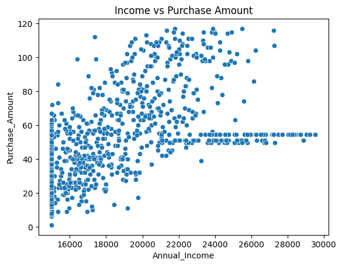

```
Correlation between Income and Purchase Amount: 0.5776716401212647
```

```python
# Correlation and visualization
 sns.scatterplot(data=data, x='Annual_Income', y='Purchase_Amount')
 plt.title('Income vs Purchase Amount')
 plt.show()
 # Correlation coefficient
 correlation = data['Annual_Income'].corr(data['Purchase_Amount'])
 print(f"Correlation between Income and Purchase Amount: {correlation}")
```

The scatter plot shows a general upward trend between annual income and purchase amount, indicating a positive correlation. However, the relationship is not perfectly linear.

Correlation:

The correlation coefficient of 0.5777 indicates a moderate positive correlation between income and purchase amount. This means that as income increases, there is a tendency for purchase amounts to also increase, but the relationship is not strong.

Conclusions:

Income and Purchase Amount: While there is a positive correlation, it's not a perfect one. This suggests that other factors besides income might influence purchase behavior.

Affluence and Purchasing Behavior: Customers with higher incomes tend to spend more, but the relationship is not straightforward. There are customers with high incomes who spend less and customers with lower incomes who spend more.

Other Factors: Factors like lifestyle preferences, brand loyalty, and product category preferences might also play a significant role in determining purchase amounts.

Recommendations:

Targeted Marketing: Marketers can use income as a segmentation variable to target specific customer groups with relevant products and offers.

Product Offerings: Offer a range of products to cater to different income levels, from budget-friendly options to premium products.

Personalized Marketing: Analyze customer data to understand individual preferences and tailor marketing messages accordingly.

Loyalty Programs: Implement loyalty programs to encourage repeat purchases and build customer relationships.

c) Ad Exposure and CTR Relationship

[figure not shown]

```
Correlation between Ad Exposure and CTR: 0.19189433805769052
```

```python
sns.scatterplot(data=data, x='Ad_Exposure', y='Click_Through_Rate')
 plt.title('Income vs Purchase Amount')
 plt.show()
 # Correlation coefficient
 correlation = data['Ad_Exposure'].corr(data['Click_Through_Rate'])
 print(f"Correlation between Ad Exposure and CTR: {correlation}")
```

d) Age and Purchase Behavior

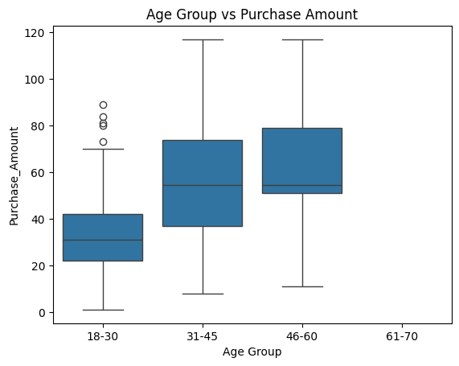

```python
# Age group vs Purchase Amount
sns.boxplot(data=data, x='Age Group', y='Purchase_Amount')
plt.title('Age Group vs Purchase Amount')
plt.show()
```

From this chart we can see

Increasing Trend: As the age group increases, the median purchase amount also tends to increase. This suggests that older customers might be making larger purchases compared to younger customers.

Outliers: The presence of outliers, especially in the 18-30 age group, indicates that there are some younger customers who make significantly larger purchases.

Underlying Reasons for Differences

Income: Older customers might have higher incomes and disposable incomes, allowing them to make larger purchases.

Lifestyle: Older customers might have different lifestyles and priorities compared to younger customers. They might be more likely to invest in home improvements, vacations, or retirement savings.

Family Size: Older customers might have larger families and therefore need to make larger purchases for household items.

Brand Loyalty: Older customers might be more brand loyal and willing to pay a premium for trusted brands.

Product Preferences: Different age groups might have different product preferences. For example, younger customers might be more interested in technology and fashion, while older customers might prefer home goods and luxury items.

e) Ad Effectiveness Across Product Categories

```python
# Ad Exposure and Purchase Amount for different categories
ad_category = data.groupby('Product_Category')[['Ad_Exposure', 'Purchase_Amount']].mean()
print(ad_category)
```

```
                  Ad_Exposure  Purchase_Amount
Product_Category
Clothing             1.779923        51.239836
Electronics          1.870445        48.499956
Furniture            1.778761        50.008740
Groceries            1.689469        48.698125
```

The table shows the average ad exposure and purchase amount for four product categories: Clothing, Electronics, Furniture, and Groceries. Here are the key observations:

Similar Ad Exposure: The ad exposure for all four categories is relatively close, with values ranging from 1.689 to 1.870. This suggests that customers are exposed to a similar number of ads for each category.

Impact of Ad Exposure on Purchase Behavior

While the table doesn't directly show a causal relationship between ad exposure and purchase behavior, we can make some inferences:

Product Category Influence: The differences in purchase amounts across categories are likely driven by factors other than ad exposure. These factors could include product price, perceived value, and consumer preferences.

Limited Impact of Ad Exposure: Given the similar ad exposure for all categories, it's unlikely that ad exposure is the primary driver of purchase behavior. Other marketing strategies, such as product promotion, pricing, and branding, might play a more significant role.